# Alpha and beta diversity across animal host species

Rajani and Mike

2019-08-25

## Setup

```r
library(speedyseq) # Use speedyseq for faster tax_glom()'s.
# library(phyloseq) # Can use phyloseq if speedyseq not installed
library(tidyverse)
library(here)
library(ggbeeswarm)
library(ggthemes)
library(cowplot)
# Custom functions and plot setup
source(here("analysis", "functions-and-ggplot-setup.R"))
```

Load the microbiome profiles, excluding the single Alpaca and Avian sample.

```r
ps <- readRDS(here("results", "ps.Rds")) %>%
    subset_samples(Host_species %in% c("Canine", "Feline", "Equine",
            "Ovine")) %>%
    filter_taxa(function (x) sum(x) > 0, prune = TRUE)
ps
```

```
## phyloseq-class experiment-level object
## otu_table()   OTU Table:         [ 9928 taxa and 193 samples ]
## sample_data() Sample Data:       [ 193 samples by 22 sample variables ]
## tax_table()   Taxonomy Table:    [ 9928 taxa by 8 taxonomic ranks ]
## refseq()      DNAStringSet:      [ 9928 reference sequences ]
```

We consider a sample as CD positive if CD was detected either the lab assay or in the microbiome sequencing profiles.

```r
sample_data(ps)$CD <- sample_data(ps)$CD_either
sam <- sample_data(ps) %>% as_tibble
glimpse(sam)
```

```
## Observations: 193
## Variables: 24
## $ Sample                                 <chr> "CS1_EQ1", "CS10_OV3", "C…
## $ Host_species                           <chr> "Equine", "Ovine", "Canin…
## $ Breed                                  <chr> "Oldenburg", NA, "Black a…
## $ Age_reported                           <chr> NA, NA, "1 year", "7 year…
## $ Age_group                              <fct> Not applicable, Not appli…
## $ Age                                    <dbl> NA, NA, 1.0000000, 7.0000…
## $ SexCS                                  <fct> MC, M, M, FS, FS, MC, F, …
## $ Sex                                    <fct> M, M, M, F, F, M, F, F, N…
## $ Neutered                               <fct> Yes, No, No, Yes, Yes, Ye…
## $ Ab_status                              <fct> Non-treated, Non-treated,…
## $ Ab_type                                <chr> "None reported", NA, "met…
## $ Ab_group                               <chr> NA, NA, "Nitroimidazole",…
## $ GI_status                              <fct> Healthy, Healthy, Healthy…
## $ CD_lab                                 <fct> Negative, Negative, Negat…
## $ CD_toxigenic                           <fct> Negative, Negative, Negat…
## $ CD_ribotype                            <chr> "Negative", "Negative", "…
## $ Relevant_diagnosis_or_reason_for_visit <chr> "Fever and leukopenia - r…
## $ Sample_number                          <int> 1, 10, 100, 101, 102, 103…
## $ Sequence_ID                            <chr> "CS1-EQ1", "CS10", "CS100…
## $ Year_sequenced                         <fct> 2018, 2017, 2018, 2018, 2…
## $ Sample_sum                             <dbl> 19019, 24720, 20789, 2197…
## $ CD_reads                               <dbl> 0, 0, 0, 0, 0, 0, 5, 264,…
## $ CD_either                              <fct> Negative, Negative, Negat…
## $ CD                                     <fct> Negative, Negative, Negat…
```

Our question is primarily whether CD presence affects the *rest* of the microbiome, so we might want to prune the Cdiff reads before doing our alpha and beta divsity analysis. This pruning will likely make very little difference to the results, because Cdiff tends to be low a very low percentage of the community:

```r
sam %>%
    filter(CD_reads > 0) %>%
    mutate(Proportion_CD = CD_reads / Sample_sum) %>%
    {summary(.$Proportion_CD)}
```

```
##      Min.   1st Qu.    Median      Mean   3rd Qu.      Max.
## 0.0002346 0.0006569 0.0061083 0.0107715 0.0123313 0.0641462
```

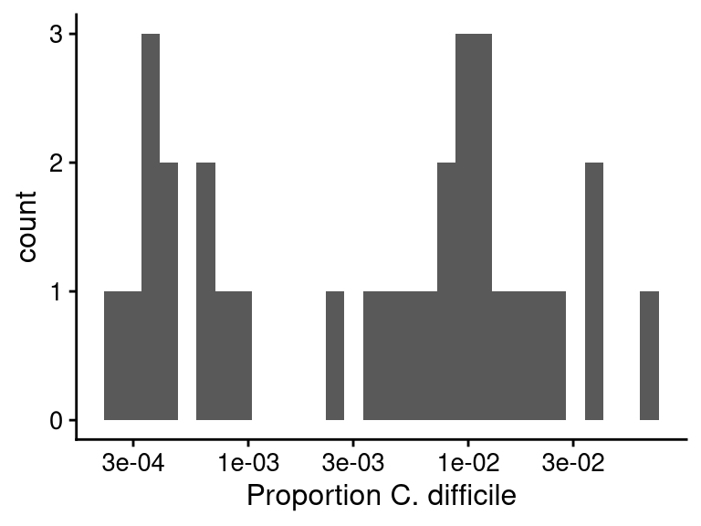

```r
sam %>%
    filter(CD_reads > 0) %>%
    ggplot(aes(CD_reads / Sample_sum)) +
    geom_histogram() +
    scale_x_log10() +
    labs(x = "Proportion C. difficile")
```

and the alpha and beta diversity measures we use are not sensitive to a low-proportion taxa. However, to confirm that our results are not substantially affected by CD abundance in the profiles, we will run our analyses both ways.

```r
cdiff_asvs <- tax_table(ps) %>% as_tibble %>%
    filter(Genus == "Clostridioides", Species == "difficile") %>%
    .$Taxon
(cdiff_asvs %in% taxa_names(ps)) %>% set_names(cdiff_asvs)
```

```
##   ASV82 ASV1962 ASV2073
##    TRUE    TRUE    TRUE
```

```r
# Uncomment to remove C. difficile ASVs from the community profiles
# ntaxa(ps)
# ps <- prune_taxa(setdiff(taxa_names(ps), cdiff_asvs), ps)
# ntaxa(ps)
# (cdiff_asvs %in% taxa_names(ps)) %>% set_names(cdiff_asvs)
```

Convert profiles to proportions, and get versions aggregated to the genus and family ranks

```r
ps <- ps %>%
    transform_sample_counts(function (x) x / sum(x))
# Note, ASVs without the relevant taxonomic assignment will be discarded
psf <- ps %>%
    tax_glom("Family") %>%
    transform_sample_counts(function (x) x / sum(x))
psg <- ps %>%
    tax_glom("Genus") %>%
    transform_sample_counts(function (x) x / sum(x))
```

## Alpha and beta diversity across hosts

### Alpha diversity

We use the `diversity()` function in the `vegan` package to calculate the Inverse Simpson diversity index at the ASV, Genus, and Family level and add these to `sample_data(ps)`.

```r
invsimp.family <- vegan::diversity(otu_table(psf), index = "invsimpson",
    MARGIN = 1)
invsimp.genus <- vegan::diversity(otu_table(psg), index = "invsimpson",
    MARGIN = 1)
invsimp.asv <- vegan::diversity(otu_table(ps), index = "invsimpson",
    MARGIN = 1)
# Check the output
head(invsimp.family)
```

```
##    CS1_EQ1   CS10_OV3 CS100_CN59 CS101_CN60  CS102_FL7 CS103_CN61
##  12.225868   9.147957   5.332248   2.138047   4.033600   8.878530
```

```r
head(invsimp.genus)
```

```
##    CS1_EQ1   CS10_OV3 CS100_CN59 CS101_CN60  CS102_FL7 CS103_CN61
##  12.210650  14.551801   5.807628   2.386502   5.091455  10.229674
```

```r
head(invsimp.asv)
```

```
##    CS1_EQ1   CS10_OV3 CS100_CN59 CS101_CN60  CS102_FL7 CS103_CN61
##  78.728452  52.421395  17.591846   2.671035  12.818023  13.455389
```

```r
# In the same order as the phyloseq samples
all(names(invsimp.family) == sample_names(ps))
```

```
## [1] TRUE
```

```r
all(names(invsimp.genus) == sample_names(ps))
```

```
## [1] TRUE
```

```r
# Add to the sample data in `ps`
sample_data(ps)$InvSimp.Family <- invsimp.family
sample_data(ps)$InvSimp.Genus <- invsimp.genus
sample_data(ps)$InvSimp.ASV <- invsimp.asv
```

For plotting, let’s get a data frame with the sample metadata and the diversity measures gathered into “tidy” form,

```r
div <- sample_data(ps) %>%
    as_tibble %>%
    gather("Index.Rank", "Diversity",
        starts_with("InvSimp"), starts_with("Richness"),
        starts_with("Shannon")) %>%
    separate("Index.Rank", c("Index", "Rank"), sep = "\\.") %>%
    mutate(
        Rank = factor(Rank, levels = c("Family", "Genus", "ASV")),
        Index = factor(Index, levels = c("InvSimp", "Shannon", "Richness"))
        )
div %>%
    select(Sample, Host_species, Index:Diversity)
```

```
## # A tibble: 579 x 5
##    Sample     Host_species Index   Rank   Diversity
##    <chr>      <chr>        <fct>   <fct>      <dbl>
##  1 CS1_EQ1    Equine       InvSimp Family     12.2
##  2 CS10_OV3   Ovine        InvSimp Family      9.15
##  3 CS100_CN59 Canine       InvSimp Family      5.33
##  4 CS101_CN60 Canine       InvSimp Family      2.14
##  5 CS102_FL7  Feline       InvSimp Family      4.03
##  6 CS103_CN61 Canine       InvSimp Family      8.88
##  7 CS104_EQ28 Equine       InvSimp Family      9.48
##  8 CS105_EQ29 Equine       InvSimp Family      7.94
##  9 CS106_CN62 Canine       InvSimp Family      7.52
## 10 CS107_EQ30 Equine       InvSimp Family     12.1
## # … with 569 more rows
```

The Inverse Simpson index is not sensitive to rare taxa and so should not be significantly affected by read depth in the range of read depths of our samples. We can confirm by plotting diversity against read depth and making sure there is not an increasing pattern,

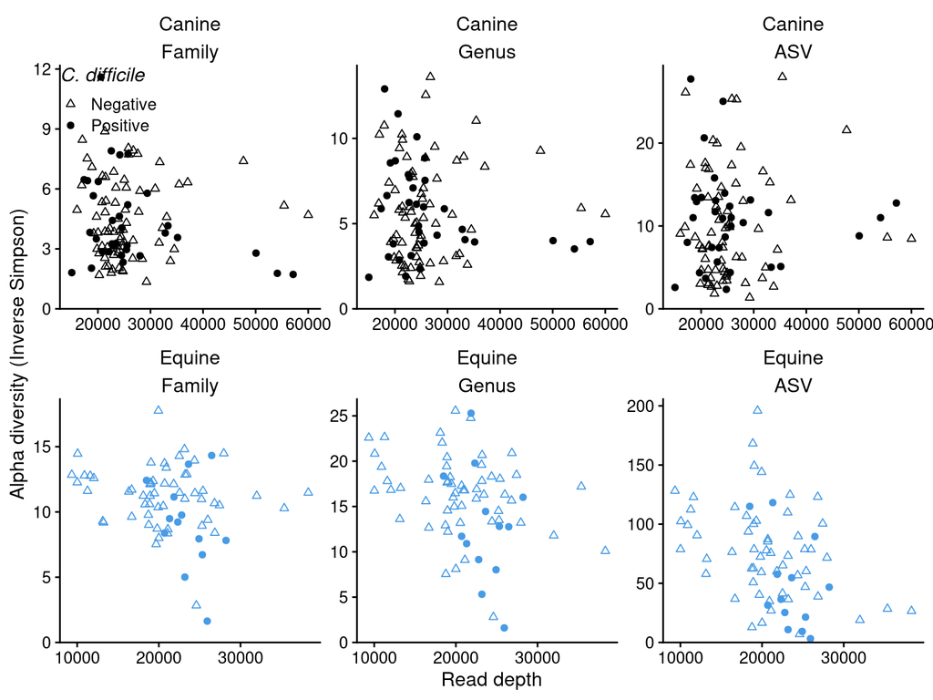

```r
div %>%
    filter(Host_species %in% c("Canine", "Equine"), Index == "InvSimp") %>%
    ggplot(aes(Sample_sum, Diversity, color = Host_species, shape = CD)) +
    geom_point() +
    facet_wrap(Host_species~Rank, scales = "free") +
    expand_limits(y = 0) +
    scale_color_manual(values = colors.host_species, guide = FALSE) +
    scale_shape_manual(values = shape.cd) +
    labs(x = "Read depth", y = "Alpha diversity (Inverse Simpson)",
        shape = italicize("C. difficile")) +
    scale_y_continuous(expand = expand_scale(mult = c(0, 0.05))) +
    theme(axis.line.x=element_line(), axis.line.y=element_line(),
        legend.position=c(0,1), legend.justification=c(0,1)
    )
```

```r
p1 <- div %>%
    mutate(Host_species = fct_reorder(Host_species, Diversity)) %>%
    ggplot(aes(Host_species, Diversity, color = Host_species, shape = CD)) +
    geom_quasirandom() +
    facet_wrap(~Rank, scales = "free") +
    expand_limits(y = 0) +
    scale_color_manual(values = colors.host_species, guide = FALSE) +
    scale_shape_manual(values = shape.cd) +
    labs(x = "Host species", y = "Alpha diversity (Inverse Simpson)",
        shape = italicize("C. difficile")) +
    scale_y_continuous(expand = expand_scale(mult = c(0, 0.05))) +
    theme(legend.position=c(0,1), legend.justification=c(0,1))
# p1
```

### Beta diversity

We’ll perform NMDS using Bray-Curtis dissimilarity at the ASV level.

```r
ord <- ps %>%
    ordinate(method = "NMDS", distance = "bray", trymax = 50)
```

```
## *** No convergence -- monoMDS stopping criteria:
##     50: stress ratio > sratmax
```

```r
p2 <- plot_ordination(ps, ord, color = "Host_species",
    shape = "CD", type="samples") +
    geom_point() +
    scale_color_manual(values = colors.host_species) +
    scale_shape_manual(values = shape.cd) +
    labs(color = "Host species", shape = italicize("C. difficile"))
# p2
```

### Figure for manuscript

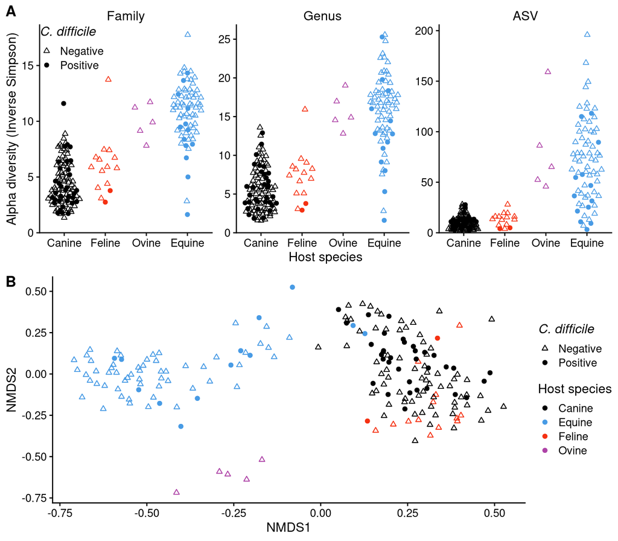

```r
cowplot::plot_grid(p1, p2,
    nrow=2, labels = "AUTO")
```

## Alpha diversity and *C. difficile* in canines and equines

Here we test for an association of *C. difficile* with alpha diversity in canines and equines, the only species with a substantial number of CD+ samples,

First, get a data frame subset to just canines and equines,

```r
div0 <- div %>%
    filter(Host_species %in% c("Canine", "Equine"))
```

Create a 2-panel figure, showing diversity in CD- and CD+ samples, at the three taxonomic ranks, for the two hosts,

```r
div0.split <- div0 %>%
    mutate(Host_copy = Host_species) %>%
    group_by(Host_copy) %>%
    nest %>%
    arrange(Host_copy) %>%
    mutate(plot = map2(Host_copy, data,
        ~ggplot(.y, aes(CD, Diversity, color = Host_species, shape = CD)) +
            stat_summary(
                fun.ymin = function(z) { quantile(z,0.25) },
                fun.ymax = function(z) { quantile(z,0.75) },
                fun.y = median, shape = 95, fatten = 20) +
            geom_quasirandom() +
            facet_wrap(~Rank, scales = "free") +
            expand_limits(y = 0) +
            scale_color_manual(values = colors.host_species, guide = FALSE) +
            scale_shape_manual(values = shape.cd) +
            labs(x = italicize("C. difficile"),
                y = "Alpha diversity (Inverse Simpson)",
                shape = italicize("C. difficile"),
                title = .x
                ) +
            scale_y_continuous(expand = expand_scale(mult = c(0, 0.05))) +
            theme(legend.position = "none")
        ))
```

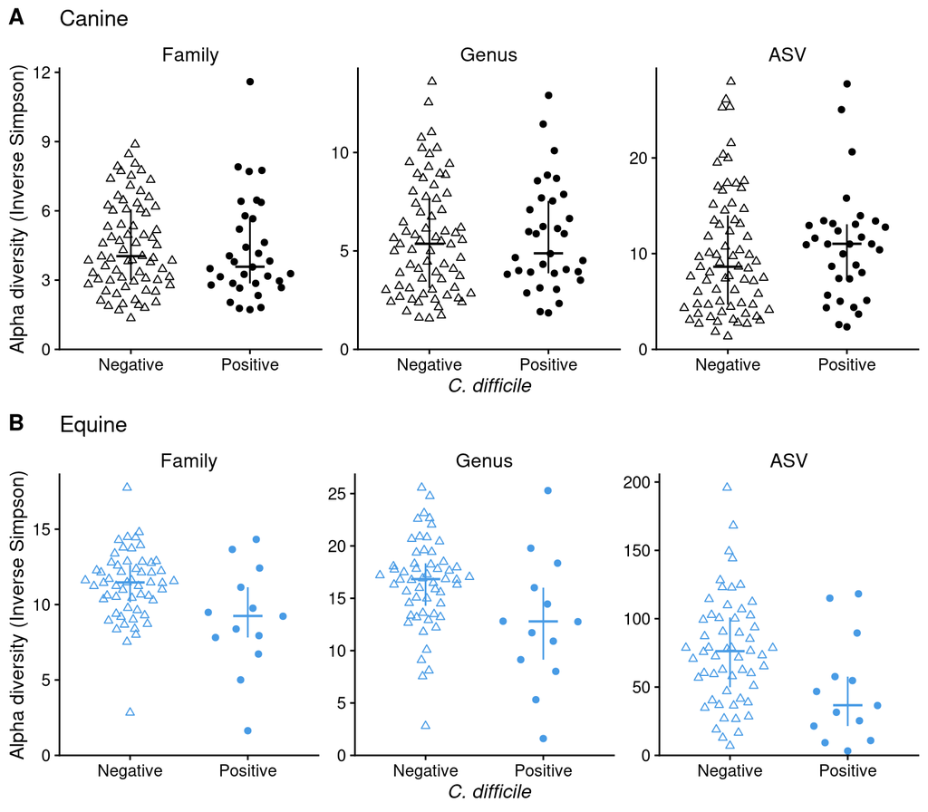

```r
plot_grid(plotlist = div0.split$plot, ncol = 1, labels = c("A", "B"))
```

Use a two-sided wilcox.test to test for higher or lower diversity in CD+/- samples, for each rank and host. The confidence intervals are for the median difference between a CD- and CD+ sample, with negative values indicating a lower diversity in CD+ samples.

```r
tb <- div0 %>%
    group_by(Host_species, Rank) %>%
    nest %>%
    mutate(fit = map(data, ~wilcox.test(data = ., -Diversity ~ CD,
                alternative = "two.sided", conf.int = TRUE, exact = TRUE))
        ) %>%
    unnest(map(fit, broom::glance)) %>%
    select(-data, -starts_with("fit")) %>%
    arrange(Host_species, Rank)
# Canines:
tb %>% filter(Host_species == "Canine") %>% select(-Host_species)
```

```
## # A tibble: 3 x 8
##   Rank   estimate statistic p.value conf.low conf.high method   alternative
##   <fct>     <dbl>     <dbl>   <dbl>    <dbl>     <dbl> <chr>    <chr>
## 1 Family   -0.272      1058   0.432    -1.09     0.452 Wilcoxo… two.sided
## 2 Genus     0.138      1202   0.835    -1.09     1.22  Wilcoxo… two.sided
## 3 ASV       1.14       1306   0.351    -1.32     3.58  Wilcoxo… two.sided
```

```r
# Equines:
tb %>% filter(Host_species == "Equine") %>% select(-Host_species)
```

```
## # A tibble: 3 x 8
##   Rank   estimate statistic p.value conf.low conf.high method   alternative
##   <fct>     <dbl>     <dbl>   <dbl>    <dbl>     <dbl> <chr>    <chr>
## 1 Family    -2.22       209  0.0165    -3.79    -0.415 Wilcoxo… two.sided
## 2 Genus     -4.06       212  0.0188    -6.97    -0.752 Wilcoxo… two.sided
## 3 ASV      -31.6        202  0.0120   -54.6     -6.60  Wilcoxo… two.sided
```

## Beta diversity and *C. difficile* in canines and equines

Here we perform a permanova test using the adonis2 function in vegan to identify if there is a significant difference in the microbiome profiles between CD+ and CD- samples within animal groups canine and equine. As above, we use Bray-Curtis similarity, but we only examine the ASV-level profiles.

```r
set.seed(1234)
#### Canine
ps.canine <- ps %>%
    subset_samples(Host_species == "Canine") %>%
    filter_taxa(function (x) sum(x) > 0, prune = TRUE)
# Calculate Bray-Curtis dissimilarity between samples:
bray.canine <- phyloseq::distance(ps.canine, method = "bray")
# Create sample-data data frames for adonis2
df.canine <- data.frame(sample_data(ps.canine))
# Permanova
(perm.canine <- vegan::adonis2(bray.canine ~ CD, data = df.canine,
        permutations = 4e4))
```

```
## Permutation test for adonis under reduced model
## Terms added sequentially (first to last)
## Permutation: free
## Number of permutations: 40000
##
## vegan::adonis2(formula = bray.canine ~ CD, data = df.canine, permutations = 40000)
##           Df SumOfSqs      R2      F   Pr(>F)
## CD         1    0.948 0.02586 2.7074 0.002075 **
## Residual 102   35.718 0.97414
## Total    103   36.666 1.00000
## ---
## Signif. codes:  0 '***' 0.001 '**' 0.01 '*' 0.05 '.' 0.1 ' ' 1
```

```r
#### Equine
ps.equine <- ps %>%
    subset_samples(Host_species == "Equine") %>%
    filter_taxa(function (x) sum(x) > 0, prune = TRUE)
# Calculate Bray-Curtis dissimilarity between samples:
bray.equine <- phyloseq::distance(ps.equine, method = "bray")
# Create sample-data data frames for adonis2
df.equine <- data.frame(sample_data(ps.equine))
# Permanova
(perm.equine <- vegan::adonis2(bray.equine ~ CD, data = df.equine,
        permutations = 4e4))
```

```
## Permutation test for adonis under reduced model
## Terms added sequentially (first to last)
## Permutation: free
## Number of permutations: 40000
##
## vegan::adonis2(formula = bray.equine ~ CD, data = df.equine, permutations = 40000)
##          Df SumOfSqs      R2      F   Pr(>F)
## CD        1    0.789 0.02998 2.0705 0.000275 ***
## Residual 67   25.530 0.97002
## Total    68   26.319 1.00000
## ---
## Signif. codes:  0 '***' 0.001 '**' 0.01 '*' 0.05 '.' 0.1 ' ' 1
```